# အသပြာဆရာဝန်တွေလား

RQuesT

2026-06-07

## နောက်ခံအချက်အလက်

မြန်မာနိုင်ငံက ဆရာဝန်တွေက တကယ်ပဲ အသပြာဆရာဝန်တွေလား။ ကျွန်တော်တို့တွေ ဆေးရုံဆေးခန်းကို သွားတဲ့အခါ ဆေးကုသမှု ကုန်ကျစရိတ်တွေကြောင့် စိတ်ပင်ပန်းရတာ ပုံမှန်လို ဖြစ်နေပါပြီ။ ဆရာဝန်စမ်းသပ်ခ၊ ဓာတ်မှန်ရိုက်၊ သွေးစစ်၊ ဆီးစစ်၊ ဆေးဖိုးနဲ့ ကျန်တဲ့ အထွေထွေ စရိတ်စကတွေကို ပေါင်းလိုက်ရင် ကုန်ကျငွေဟာ တနင့်တပိုးပါပဲ။ ကုန်ကျငွေနဲ့ ယှဉ်လိုက်ရင် ကိုယ်ပြန်ရတဲ့ စိတ်ကျေနပ်မှု၊ ဝေဒနာသက်သာတာတွေက ဘယ်တော့မှ တန်တယ်လို့ မခံစားရပါဘူး။ အထူးသဖြင့် ပုဂ္ဂလိက အထူးကုဆေးခန်းကြီးတွေမှာ ဆိုရင် အခြေခံလူတန်းစားတွေ လက်လှမ်းမမီနိုင်တဲ့ ငွေကြေးပမာဏကို ကျန်းမာရေး စောင့်ရှောက်မှုအတွက် ပေးချေနေရတာပါပဲ။

ခေတ်က ပိုပိုပြီး ကျပ်တည်းလာတာနဲ့အမျှ နေမကောင်းဖြစ်မှာကို စိုးလာရတယ်။ တစ်ခါတစ်ခါ ဆေးခန်းသွားလိုက်ရရင် ကုန်တာက နင့်ခနဲမို့ ဆေးကုသမှုခံယူဖို့ဆိုတာ တွန့်ဆုတ်နေကြရတယ်။ ဒီအခြေအနေမှာ Facebook လူမှုကွန်ယက်မှာ ဆရာဝန်လူတန်းစားကို မကြည်မလင်ဖြစ်လာတာတွေ ခပ်စိတ်စိတ်မြင်တွေ့လာရတယ်။ အသပြာဆရာဝန်တွေဆိုတဲ့ စကားဟာ Commentတွေမှာ မကြာမကြာ မြင်လာရပါတယ်။ ဆရာဝန်တွေဘက်ကလည်း ငွေမှမယူရင် စားဝတ်နေရေးအတွက် ဘယ်လိုလုပ်ရမှာလဲ ဆိုတာမျိုး တုံ့ပြန်လာကြတယ်။ ဆရာဝန်လူနာ ဆက်ဆံရေးဟာလည်း ခေတ်ဆိုးကြီးနဲ့အတူ ပျက်စီးလာတာကို မြင်လာရတော့တာပါပဲ။

ဒီပြဿနာတွေရဲ့ ဇစ်မြစ်ကတော့ ဆေးကုသမှု ကုန်ကျစရိတ်ပါပဲ။ ဆေးကုသမှုစရိတ်ဟာ သာမန်လူတန်းစားကို ဆင်းရဲမွဲတေတဲ့ အခြေအနေကို ရောက်အောင် ဆွဲချနိုင်တာဟာ ငြင်းမရတဲ့ အမှန်တရားပါ။ ဆရာဝန်လူနာဆက်ဆံရေးကို မပျက်စီးစေဖို့ဆိုရင် မြန်မာနိုင်ငံက ဆရာဝန်တွေဟာ တကယ်ပဲ အသပြာဆရာဝန်တွေဟုတ်မဟုတ် အတည်ပြုဖို့ လိုလာပါတယ်။

ဒါကြောင့် ဆေးကုသမှုစရိတ်တွေကို လေ့လာကြည့်ဖို့ လိုလာပါတယ်။ ဒါပေမယ့် ဆေးကုသမှုစရိတ် ဒေတာတွေဆိုတာက ရဖို့လုံးဝမလွယ်တဲ့ ဒေတာတွေဖြစ်ပါတယ်။ ဒါကြောင့် ပုဂ္ဂလိကဆေးရုံတစ်ခုက ဘောက်ချာဖြတ်ပိုင်းကိုပဲ Case study အနေနဲ့ လေ့လာကြည့်ထားပါတယ်။ ရည်ရွယ်ချက်ကတော့ ဆေးကုသစရိတ်မှာ ဘာက ဘယ်လောက်ကျသလဲနဲ့ ဆရာဝန်တွေက ဘယ်လောက်ယူသလဲ ဆိုတာကို အဓိက လေ့လာကြည့်ထားပါတယ်။

## လေ့လာမှုနည်းနာ

ပုဂ္ဂလိကအထူးကုဆေးခန်းကြီးတစ်ခုက ပါမောက္ခဆရာဝန်ကြီးတစ်ဦးနဲ့ ပုံမှန် ရက်ချိန်းပြန်ပြတဲ့ ဆေးရုံစရိတ်ကိုပဲ Case report လေးလုပ်ထားပါတယ်။ ဘောက်ချာဖြတ်ပိုင်းမှာ ပါဝင်တဲ့ item တွေကို နိုင်ငံတကာက အဓိပ္ပါယ်ဖွင့်ဆိုချက်တွေအတိုင်းပဲ ယူထားပါတယ်။ ဘောက်ချာမှာပါတာတွေကတော့

- Consultation fees (regular) ဆရာဝန်စမ်းသပ်ခ /ဆွေးနွေးခ
- OPD care and medical supplies ပြင်ပလူနာစောင့်ရှောက်ခနှင့်ဆေးပစ္စည်းဖိုး
- EMR service fee အီလက်ထရွန်နစ် ဆေးမှတ်တမ်း ဝန်ဆောင်ခ
- Assessment fee စမ်းသပ်ခ (ပေါင်ချိန်၊ အရပ်တိုင်း၊ သွေးတိုင်းဟုယူဆရ)

တို့ပါပဲ။

ဒီအချက်တွေကိုပဲ စုစုပေါင်းကုန်ကျစရိတ်ရဲ့ ဘယ်လောက်ရာခိုင်နှုန်းစီ ကျသလဲဆိုတာကို လေ့လာကြည့်ကြရအောင်။

## တွေ့ရှိချက်

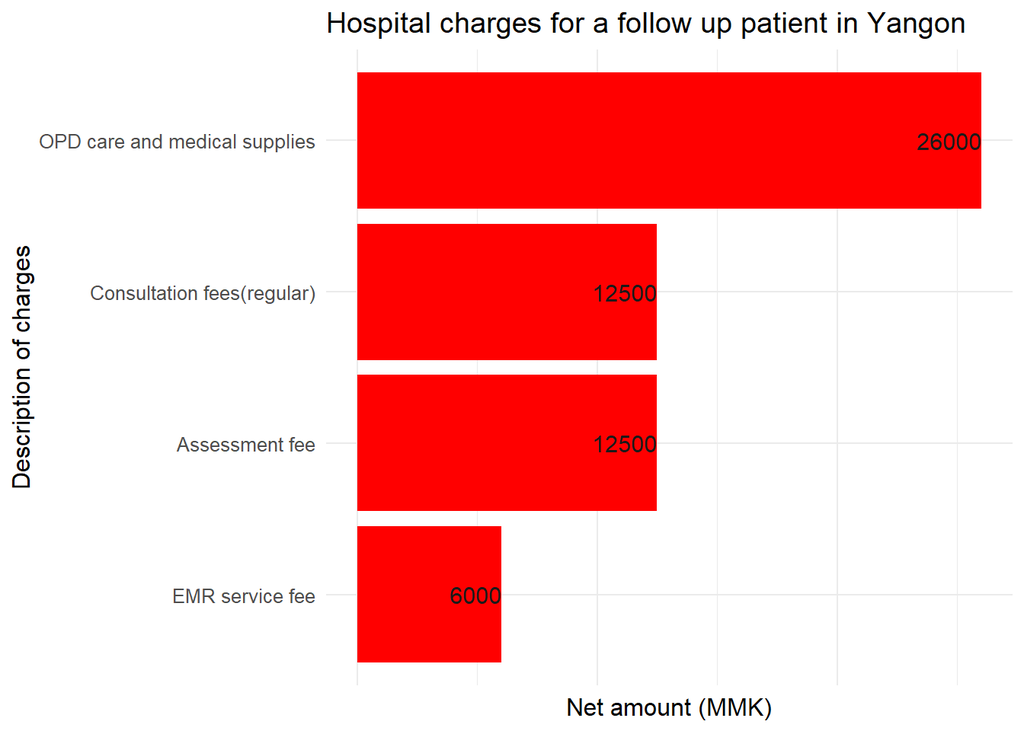

ပုံ(၁) ကုသမှုစရိတ်

ပုံ(၁)အရ ပြင်ပလူနာစောင့်ရှောက်ခနဲ့ ဆေးပစ္စည်းဖိုးက ၂၆၀၀၀ကျပ်၊ ဆရာဝန်စမ်းသပ်ခ ၁၂၅၀၀ကျပ်၊ စမ်းသပ်ခ ၁၂၅၀၀ကျပ်၊ အီလက်ထရွန်နစ် ဆေးမှတ်တမ်း ဝန်ဆောင်ခ ၆၀၀၀ စုစုပေါင်း ၅၇၀၀၀ကျပ် ကုန်ကျပါတယ်။

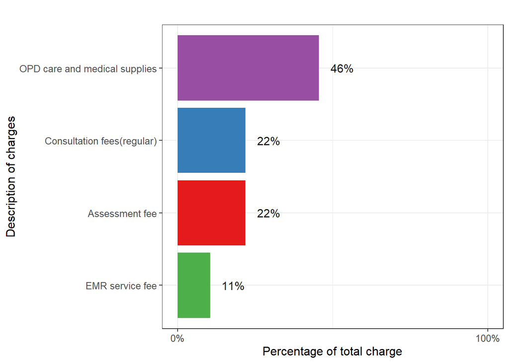

ပုံ(၂) ကုသမှုစရိတ်ကို အချိုးကျခွဲခြမ်းစိတ်ဖြာခြင်း

ပုံ(၂)အရ ကုသမှုစရိတ် စုစုပေါင်းရဲ့ တစ်ဝက်နီးပါး (၄၆%)ဟာ ပြင်ပလူနာစောင့်ရှောက်ခနဲ့ ဆေးပစ္စည်းဖိုးဖြစ်ပါတယ်။

ဆရာဝန်စမ်းသပ်ခနဲ့ သွေးပေါင်ချိန်တိုင်း ပေါင်ချိန်တာတွေက လေးပုံတစ်ပုံမပြည့်တဲ့ ၂၂% စီဖြစ်ကြပါတယ်။

အီလက်ထရွန်နစ် ဆေးမှတ်တမ်းအတွက်က ၁၀ပုံ တစ်ပုံ(၁၁%)ပါ။

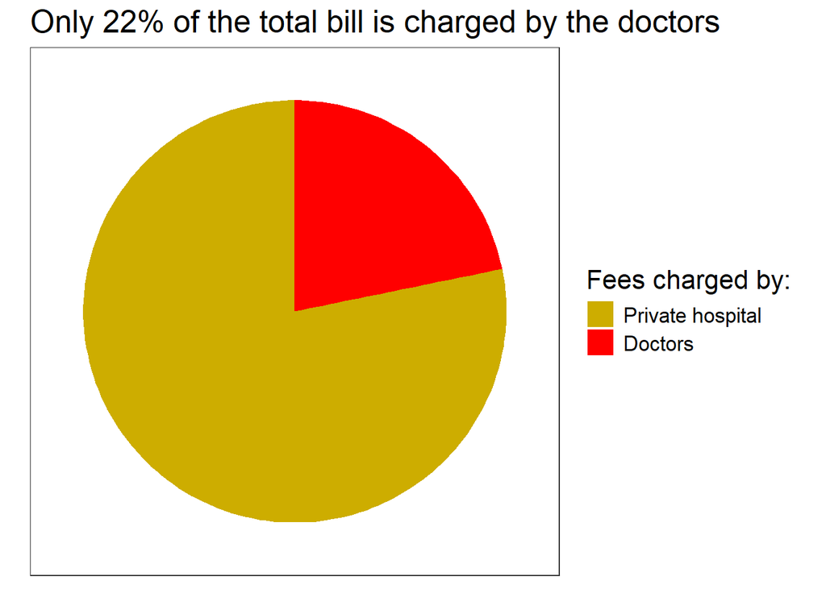

ပုံ(၃) ဆရာဝန်ရရှိသော ရာခိုင်နှုန်း

ပုံ(၃)အရ ဆရာဝန်ကို လူနာကပေးရတဲ့ငွေက လေးပုံတစ်ပုံမပြည့်တဲ့ ၂၂ % ပါ။

ကုန်ကျစရိတ်အများစု (၇၈%)က ပုဂ္ဂလိကဆေးရုံကို ပေးရတာဖြစ်ပါတယ်။

## ဆွေးနွေးချက်

ကျွန်တော်တို့ရဲ့ Case မှာတော့ ဆရာဝန်တွေဟာ လူနာဆီက ငွေအများကြီးတောင်းတာ မတွေ့ရပါဘူး။ လူနာတွေရဲ့ ကုန်ကျစားရိတ် အများစုက ဆေးရုံကိုပေးရတာဖြစ်ပါတယ်။

ပေးရတာတွေကို တစ်ခုချင်းပြန်ကြည့်ရင် အနည်းဆုံးက အီလက်ထရွန်နစ် ဆေးမှတ်တမ်းဝန်ဆောင်ခ ဖြစ်ပါတယ်။ ဒီဝန်ဆောင်ခက ကျွန်တော်တို့ကို ဘာတွေဝန်ဆောင်မှုပေးနေပါသလဲ။ ယူကေလိုနိုငံတွေမှာလို ခရီးသွားလာရင်း ဆေးခန်းပြရတဲ့အခါ ကိုယ့်မှတ်ပုံတင်ပြလိုက်တာနဲ့ ကိုယ့်ဆေးကုသမှုမှတ်တမ်း ရောဂါရာဇဝင်တွေကို ဆရာဝန်က တန်းသိနိုင်တဲ့ အဆင့်ကို မရောက်နိုင်သေးတာတော့ လက်ခံရပါမယ်။ ဒါဆိုရင် နိုင်ငံရပ်ခြားဆေးကုသွားတဲ့အခါ ဒီမှတ်တမ်းကို သုံးလို့ရမှာလား ဒါကို ကျွန်တော်တို့ မသိနိုင်ပါဘူး။ အနည်းဆုံးတော့ ဒီပုဂ္ဂလိကဆေးရုံမှာပဲ အထူးကုတစ်ယောက်ကနေ တခြားအထူးကုဆီကို ပြောင်းပြတဲ့အခါ ဒီမှတ်တမ်းက အလိုအလျောက် ဆရာဝန်ဆီကို ပို့ပေးသလားမေးကြည့်ရာမှာတော့ သက်ဆိုင်ရာဆရာဝန်ရဲ့ ခွင့်ပြုချက်ရမှထုတ်ပေးနိုင်မယ်လို့ ကောင်တာကဝန်ထမ်းကပြောပါတယ်။ ဒီလိုဆို ကျွန်တော်တို့ ဆေးရုံသွားတဲ့အခါ ဆေးစာအုပ် ဆေးစစ်အဖြေတစ်ပွေ့တစ်ပိုက်နဲ့ သွားပြစရာမလိုတော့ဘူးလားဆိုတော့လည်း မဟုတ်ပြန်ပါဘူး။ ဆေးစာအုပ်သာမက ဆေးစစ်မှတ်တမ်းတွေက ယူသွားရတုန်းပါပဲ။ ဒီတော့ အီလက်ထရွန်နစ်ဆေးမှတ်တမ်း (EMR)ဝန်ဆောင်မှုဟာ လူနာတွေဘက်က ဆန်းစစ် မေးခွန်းထုတ်သင့်တဲ့ ကိစ္စတစ်ခုဖြစ်ပါတယ်။

ဆရာဝန်စမ်းသပ်ခနဲ့ သွေးပေါင်ချိန်တိုင်း ကိုယ်အလေးချိန်ချိန်တာတွေရဲ့ ကုန်ကျစရိတ်က အတူတူပါပဲ။ ပုဂ္ဂလိကဆေးရုံကြီးတွေမှာ ပြဖူးသူတိုင်း သိကြပါလိမ့်မယ်။ သွေးပေါင်ချိန်တိုင်း ကိုယ်အလေးချိန်ချိန်တာတွေက ဒစ်ဂျစ်တယ်စက် ပစ္စည်းတွေနဲ့လုပ်ကြတာ ဖြစ်ပါတယ်။ ဒီစရိတ်က ဆရာဝန်စမ်းသပ်ခနဲ့ တူတူဖြစ်နေတာက အံ့ဩစရာကောင်းပါတယ်။ လှည်းတန်းသွားရင်း ကိုယ်အလေးချိန်ချိန်တာ ရပ်ကွက်ထဲက ခင်ရာမင်ရာအိမ် ဒါမှမဟုတ် ရပ်ကွက်ဆေးခန်းမှာ သွေးပေါင်ချိန်တာနဲ့ယှဉ်ရင် ၁၂၅၀၀ကျပ်ဆိုတာ များတယ်လို့ယူဆနိုင်ပါတယ်။

ဆရာဝန်စမ်းသပ်ခက ဒါနဲ့ အတူတူဖြစ်နေတာကမြင်သာအောင်ပြောရရင် ကိုယ်ကိုင်တဲ့ အိုင်ဖုန်းဘက်ထရီလဲတာကို မှန်မကွဲကပ်တဲ့ဈေးနဲ့ လဲပေးလိုက်သလိုပါပဲ။ ဓာတ်ဆီတစ်လီတာကို ရေသန့်ဘူးတစ်ဘူးဖိုးနဲ့ ဆီဆိုင်ကရောင်းပေးနေသလိုပေါ့။ တကယ့် လက်တွေ့မှာသာ ဖုန်းဆိုင်က အိုင်ဖုန်းဘက်ထရီကို မှန်မကွဲဈေးနဲ့လဲပေးရင် ပျော်မှာဖြစ်ပေမယ့် ဒီလိုဈေးနဲ့ ဆရာဝန်စမ်းသပ်ခပေးရတာကို များတယ်ထင်နေတာကတော့ မဖြစ်သင့်ပါဘူး။ များတယ်လို့ထင်နေရင် ကိုယ့်ခန္ဓာကိုယ်က ဖုန်းတစ်လုံးလောက်မှ တန်ဖိုးမရှိဘူး ကိုယ့်ကျန်းမာရေးက အရေးမကြီးဘူးလို့ ခံယူထားသလိုဖြစ်နေပါလိမ့်မယ်။ ဆရာဝန်တွေဘက်ကလည်း ကိုယ့်သိမှု ကိုယ့်အတတ်ပညာက ဈေးပေါလွန်းနေတာကို သက်ဆိုင်ရာ ဆေးရုံတွေနဲ့ ညှိနှိုင်းသင့်ပါတယ်။

ကုန်ကျစရိတ် တဝက်နီးပါးဖြစ်တဲ့ ပြင်ပလူနာစောင့်ရှောက်ခနဲ့ ဆေးပစ္စည်းဖိုးဆိုတာက အခုကိစ္စမှာ ဘာကိုဆိုလိုသလဲဆိုတာ မေးခွန်းထုတ်ဖို့ကောင်းပါတယ်။ ဆရာဝန်ချိန်းလို့ နေကောင်းလျက်နဲ့ ဆေးခန်းလာပြတဲ့သူကို ပြင်ပလူနာဌာနမှာ ငုတ်တုတ်ထိုင်စောင့်နေရုံနဲ့ ၂၆၀၀၀ကျပ်ဆိုတာက တော်တော်များတဲ့ပမာဏပါ။ ဆေးစာအုပ်ဖိုး လူနာကို ဝှီးချဲနဲ့တွန်းပေးရတာတွေအတွက် ဆိုလည်း များနေပါသေးတယ်။ ဆေးပစ္စည်ဖိုးဆိုတာက စောစောက သွေးပေါင်ချိန်တိုင်းကိရိယာတွေ ပေါင်ချိန်စက်တွေ အတွက်ဆိုရင် အဲ့အတွက်ယူထားတဲ့ စမ်းသပ်ခဆိုတာကကောလို့ ပြန်မေးချင်စရာပါ။ ဒီတော့ ကုန်ကျစရိတ်ရဲ့ အများဆုံးရာခိုင်နှုန်းက မြေဖိုး အဆောက်အအုံဖိုး ကိုယ့်အလှည့်ရောက်မှာကို ထိုင်စောင့်ဖို့ ထိုင်ခုံဖိုး လျှပ်စစ်မီတာခ အဲကွန်းဖိုး စောင့်ရင်း အီးပါဖို့ အိမ်သာသန့်ရှင်းရေး အိမ်သာရေ စတာတွေအတွက် ကုန်ကျတာဖြစ်ပါတယ်။

ဒီလိုကုန်ကျတဲ့အတွက် ဆေးရုံဘက်ကိုလည်း အပြစ်တင်လို့ မရပါဘူး။ ဒီဘက်ခေတ်မှာ ရေဖိုး မီးဖိုး အခန်းခတွေ ထည့်မတွက်ဘဲ ဆေးဖိုးနဲ့ စမ်းသပ်ခပဲယူတဲ့ တနိုင်တပိုင်ဆေးခန်းလေးတွေဟာ ရပ်တည်ဖို့ မဖြစ်နိုင်ကြတာကို တွေ့နေရပါတယ်။ စီးပွားရေးလုပ်တာမို့ နေရာငှားခ ဝန်ထမ်းခနဲ့ အခြားအထွေထွေကုန်ကျစရိတ်တွေကို ထည့်သွင်းစဉ်းစားရသလို ထိုက်သင့်တဲ့ အမြတ်ကိုလည်း ယူရမှာ ဖြစ်ပါတယ်။ တကယ့်ပြဿနာကတော့ လူတိုင်းလက်လှမ်းမီနိုင်တဲ့ ကျန်းမာရေးအာမခံ စနစ်တစ်ခုမရှိတာနဲ့ ဆရာဝန်တွေရဲ့ လူနာနဲ့ပြောဆိုဆက်ဆံရာမှာ အားနည်းချက်ရှိနေတာတွေပဲ ဖြစ်ပါတယ်။

ဒီ Case study မှာ အားနည်းချက်အနေနဲ့ကတော့ လူနာတစ်ယောက် ဆရာဝန်တစ်ယောက် ဆေးရုံတစ်ရုံရဲ့ တစ်ခါစာ ကုန်ကျစရိတ်ကိုသာ လေ့လာထားနိုင်တာဖြစ်ပါတယ်။ လူနာများများ ဆရာဝန်များများနဲ့ ဆေးကုသမှုစရိတ်ကို လေ့လာနိုင်ဖို့ လုပ်ပိုင်ခွင့်ရှိသူတွေ လေ့လာသင့်တဲ့၊ ဆေးကျောင်းသား ကျန်းမာရေး ကျောင်းသားများ ထပ်တိုးလေ့လာသင့်တဲ့ ကိစ္စရပ်တစ်ခုပါပဲ။

## နိဂုံးချုပ်

နိဂုံးချုပ်အနေနဲ့ ဆရာဝန်တွေကို အသပြာဆရာဝန်တွေအဖြစ် စွပ်စွဲတာကမမှန်ပါဘူး။ အဓိက ပြဿနာက ကျန်းမာရေးအာမခံ စနစ်တစ်ခု မရှိတာပါ။ ဆရာဝန်တွေဘက်ကတော့ လူနာစိတ်ကျေနပ်အောင် ကိုယ့်လူနာကို ကိုယ့်ရည်းစားလို သဘောထားပြီး စိတ်ခံစားချက်ကို ဂရုစိုက်နားထောင်ပေးဖို့ တစ်လောကလုံးမှာ စိတ်ဝင်စားစရာ အကောင်းဆုံးသူအဖြစ် ဆက်ဆံပေးဖို့ တိုက်တွန်းချင်တာပါပဲ။